[figure not shown]

## DERFE-Dirección de Estadística

# A crash course on Data Science with Python

## Motivation

### Part I: Data Science

[figure not shown]

### Part II: Become an expert in Data Science

[figure not shown]

### Part III: What language to choose? Python vs R

[figure not shown]

### Homework:

- Python's history

https://en.wikipedia.org/wiki/History_of_Python

- Basics of Python

https://www.learnpython.org/

https://realpython.com/jupyter-notebook-introduction/

- Choosing R or Python for Data Analysis? An Infographic

https://www.datacamp.com/community/tutorials/r-or-python-for-data-analysis#gs.nrBsDZQ

- Why become a data scientist?

https://365datascience.com/defining-data-science/

- Comparisons between languages

https://www.codingame.com/blog/best-programming-language-learn-2019/

https://towardsdatascience.com/data-science-101-is-python-better-than-r-b8f258f57b0f

https://www.tiobe.com/tiobe-index/

http://pypl.github.io/PYPL.html

https://redmonk.com/sogrady/2018/03/07/language-rankings-1-18/

https://octoverse.github.com/projects#languages

- Visualizations in Python

https://towardsdatascience.com/5-quick-and-easy-data-visualizations-in-python-with-code-a2284bae952f

## Introduction to Data Science with Python

### Part I: Learning path

[figure not shown]

### Homework:

#### Installation of Python/Anaconda/Jupyter notebook

https://www.anaconda.com/

https://www.freecodecamp.org/news/how-to-get-started-with-python-for-deep-learning-and-data-science-3bed07f91a08/

https://www.w3schools.com/python/default.asp

#### Python basic syntax

https://jupyter.org/index.html

#### Books

- How to Think Like a Computer Scientist: Learning with Python 3 Documentation
- Data Science Essentials in Python
- Introduction to Machine Learning with Python
- Think Python
- Data Science from Scratch

Check the following link: https://inemexico-my.sharepoint.com/:f:/g/personal/miguel_alvarez_ine_mx/EkVbN-eSMI5FpX1NDprCReMBJHPCbxzOCppSUtP79dCsKg?e=JVp4FE

### Part II: Jupyter notebooks

### Launching the Jupyter Notebook

To run the Jupyter Notebook, open an OS terminal, go to ~/minibook/ (or into the directory where you've downloaded the book's notebooks), and type jupyter notebook. This will start the Jupyter server and open a new window in your browser (if that's not the case, go to the following URL: http://localhost:8888).

The Notebook is most convenient when you start a complex analysis project that will involve a substantial amount of interactive experimentation with your code. Other common use-cases include keeping track of your interactive session (like a lab notebook), or writing technical documents that involve code, equations, and figures.

In the rest of this section, we will focus on the Notebook interface.

### The Notebook dashboard

The dashboard contains several tabs:

- Files shows all files and notebooks in the current directory.
- Running shows all kernels currently running on your computer.
- Clusters lets you launch kernels for parallel computing (covered in Chapter 5, High-Performance Computing).
- A notebook is an interactive document containing code, text, and other elements. A notebook is saved in a file with the .ipynb extension. This file is a plain text file storing a JSON data structure.

A kernel is a process running an interactive session. When using IPython, this kernel is a Python process. There are kernels in many languages other than Python.

In Jupyter, notebooks and kernels are strongly separated. A notebook is a file, whereas a kernel is a process. The kernel receives snippets of code from the Notebook interface, executes them, and sends the outputs and possible errors back to the Notebook interface. Thus, in general, the kernel has no notion of Notebook. A notebook is persistent (it's a file), whereas a kernel may be closed at the end of an interactive session and it is therefore not persistent. When a notebook is re-opened, it needs to be re-executed.

In general, no more than one Notebook interface can be connected to a given kernel. However, several IPython console can be connected to a given kernel.

### The Notebook user interface

To create a new notebook, click on the New button, and select Notebook (Python 3). A new browser tab opens and shows the Notebook interface:

[figure not shown]

```python
from IPython.display import Image
Image(filename='nbui-2.png')
```

Here are the main components of the interface, from top to bottom:

The notebook name, that you can change by clicking on it. This is also the name of the .ipynb file. The menu bar gives you access to several actions pertaining to either the notebook or the kernel. To the right of the menu bar is the Kernel name. You can change the kernel language of your notebook from the Kernel menu. We will see in Chapter 6, Customizing IPython how to manage different kernel languages. The toolbar contains icons for common actions. In particular, the dropdown menu showing Code lets you change the type of a cell. Below is the main component of the UI: the actual Notebook. It consists of a linear list of cells. We will detail below the structure of a cell.

### Structure of a notebook cell

There are two main types of cells: Markdown cells and code cells.

A Markdown cell contains rich text. In addition to classic formatting options like bold or italics, we can add links, images, HTML elements, LaTeX mathematical equations, and more. We will cover Markdown in more detail in the Ten Jupyter/IPython essentials section of this chapter. A code cell contains code to be executed by the kernel. The programming language corresponds to the kernel's language. We will only use Python in this book, but you can use many other languages. You can change the type of a cell by first clicking on a cell to select it, and then choosing the cell's type in the toolbar's dropdown menu showing Markdown or Code.

#### Markdown cells

Here is a screenshot of a Markdown cell:

[figure not shown]

```python
Image(filename='markdown-both.png')
```

The top panel shows the cell in edit mode, while the bottom one shows it in render mode. The edit mode lets you edit the text, while the render mode lets you display the rendered cell. We will explain the differences between these modes in greater detail below.

#### Code cells

Here is a screenshot of a complex code cell:

[figure not shown]

This code cell contains several parts:

- The prompt number shows the cell's number. This number increases everytime you run the cell. Since you can run cells of a notebook out of order, nothing guarantees that code numbers are linearly increasing in a given notebook.
- The input area contains a multiline text editor that lets you write one or several lines of code with syntax highlighting.
- The widget area may contain graphical controls; here, it displays a slider.
- The output area can contain multiple outputs, here:
- Standard output (text in black)
- Error output (text with a red background)
- Rich output (an HTML table and an image here)

### Running Code

First and foremost, the Jupyter Notebook is an interactive environment for writing and running code. The notebook is capable of running code in a wide range of languages. However, each notebook is associated with a single kernel. This notebook is associated with the IPython kernel, therefore runs Python code.

Code cells allow you to enter and run code Run a code cell using Shift-Enter or pressing the button in the toolbar above:

```python
print("Hello world!")
```

```
Hello world!
```

```python
a = 10
a
```

```
10
```

There are two other keyboard shortcuts for running code:

- Alt-Enter runs the current cell and inserts a new one below.
- Ctrl-Enter run the current cell and enters command mode.

### Cell menu

The "Cell" menu has a number of menu items for running code in different ways. These includes:

Run and Select Below Run and Insert Below Run All Run All Above Run All Below

```python
from IPython.display import HTML, YouTubeVideo
```

```python
HTML('''
<table style="border: 2px solid black;">
''' +
     ''.join(['<tr>' +
              ''.join([f'<td>{row},{col}</td>'
                       for col in range(5)]) +
              '</tr>' for row in range(5)]) +
     '''
</table>
''')
```

| 0,0 | 0,1 | 0,2 | 0,3 | 0,4 |
| --- | --- | --- | --- | --- |
| 1,0 | 1,1 | 1,2 | 1,3 | 1,4 |
| 2,0 | 2,1 | 2,2 | 2,3 | 2,4 |
| 3,0 | 3,1 | 3,2 | 3,3 | 3,4 |
| 4,0 | 4,1 | 4,2 | 4,3 | 4,4 |

```python
YouTubeVideo('VQBZ2MqWBZI')
```

[video not shown]

### Part III: Python Basics

### Variables

Let's use Python as a calculator. Here, 2 * 2 is an expression statement. This operation is performed, the result is returned, and IPython displays it in the notebook cell's output.

TIP (Division): In Python 3, 3 / 2 returns 1.5 (floating-point division), whereas it returns 1 in Python 2 (integer division). This can be source of errors when porting Python 2 code to Python 3. It is recommended to always use the explicit 3.0 / 2.0 for floating-point division (by using floating-point numbers) and 3 // 2 for integer division. Both syntaxes work in Python 2 and Python 3. See http://python3porting.com/differences.html#integer-division for more details.

```python
2 * 2
```

```
4
```

```python
3 // 2
```

```
1
```

```python
3/2
```

```
1.5
```

Other built-in mathematical operators include +, -, ** for the exponentiation, and others. You will find more details at https://docs.python.org/3/reference/expressions.html#the-power-operator.

Variables form a fundamental concept of any programming language. A variable has a name and a value. Here is how to create a new variable in Python:

```python
a = 2
```

And here is how to use an existing variable:

```python
a * 3
```

```
6
```

Several variables can be defined at once (this is called unpacking):

```python
a, b = 2, 6
```

There are different types of variables. Here, we have used a number (more precisely, an integer). Other important types include floating-point numbers to represent real numbers, strings to represent text, and booleans to represent True/False values. Here are a few examples:

```python
somefloat = 3.1415  # The "dot" character represents the radix point.
sometext = 'pi is about'  # Use single or double quotes for strings.
print(sometext, somefloat)  # This displays several variables concatenated.
```

```
pi is about 3.1415
```

Note how we used the # character to write comments. Whereas Python discards the comments completely, adding comments in the code is important when the code is to be read by other humans (including yourself in the future).

### String escaping

String escaping refers to the ability to insert special characters in a string. For example, how can you insert ' and ", given that these characters are used to delimit a string in Python code? The backslash \ is the go-to escape character in Python (and in many other languages too). Here are a few examples:

```python
print("Hello \"world\"")
print("A list:\n* item 1\n* item 2")
print("C:\\path\\on\\windows")
print(r"C:\path\on\windows")
```

```
Hello "world"
A list:
* item 1
* item 2
C:\path\on\windows
C:\path\on\windows
```

The special character \n is the new line (or line feed) character. To insert a backslash, you need to escape it, which explains why it needs to be doubled as \.

You can also disable escaping by using raw literals with a r prefix before the string, like in the last example above. In this case, backslashes are considered as normal characters.

This is convenient when writing Windows paths, since Windows uses backslash separators instead of forward slashes like on Unix systems. A very common error on Windows is forgetting to escape backslashes in paths: writing "C:\path" may lead to subtle errors.

You will find the list of special characters in Python at https://docs.python.org/3.4/reference/lexical_analysis.html#string-and-bytes-literals

### Lists

A list contains a sequence of items. You can concisely instruct Python to perform repeated actions on the elements of a list. Let's first create a list of numbers:

```python
items = [1, 3, 0, 4, 1]
```

Note the syntax we used to create the list: square brackets [], and commas , to separate the items.

The built-in function len() returns the number of elements in a list:

```python
len(items)
```

```
5
```

Python comes with a set of built-in functions, including print(), len(), max(), functional routines like filter() and map(), and container-related routines like all(), any(), range() and sorted(). You will find the full list of built-in functions at https://docs.python.org/3.4/library/functions.html.

Now, let's compute the sum of all elements in the list. Python provides a built-in function for this:

```python
sum(items)
```

```
9
```

We can also access individual elements in the list, using the following syntax:

```python
items[0]
```

```
1
```

```python
items[-1]
```

```
1
```

Note that indexing starts at 0 in Python: the first element of the list is indexed by 0, the second by 1, and so on. Also, -1 refers to the last element, -2, to the penultimate element, and so on.

The same syntax can be used to alter elements in the list:

```python
items[1] = 9
items
```

```
[1, 9, 0, 4, 1]
```

We can access sublists with the following syntax:

Here, 1:3 represents a slice going from element 1 included (this is the second element of the list) to element 3 excluded. Thus, we get a sublist with the second and third element of the original list. The first-included/last-excluded asymmetry leads to an intuitive treatment of overlaps between consecutive slices. Also, note that a sublist refers to a dynamic view of the original list, not a copy; changing elements in the sublist automatically changes them in the original list.

```python
items[1:3]
```

```
[9, 0]
```

Python provides several other types of containers:

Tuples are immutable and contain a fixed number of elements:

```python
my_tuple = (1, 2, 3)
my_tuple[1]
```

```
2
```

Dictionaries contain key-value pairs. They are extremely useful and common:

```python
my_dict = {'a': 1, 'b': 2, 'c': 3}
print('a:', my_dict['a'])
```

```
a: 1
```

```python
print(my_dict.keys())
```

```
dict_keys(['a', 'b', 'c'])
```

There is no notion of order in a dictionary. However, the native collections module provides an OrderedDict structure that keeps the insertion order (see https://docs.python.org/3.4/library/collections.html).

Sets, like mathematical sets, contain distinct elements:

```python
my_set = set([1, 2, 3, 2, 1])
my_set
```

```
{1, 2, 3}
```

A Python object is mutable if its value can change after it has been created. Otherwise, it is immutable. For example, a string is immutable; to change it, a new string needs to be created. A list, a dictionary, or a set is mutable; elements can be added or removed. By contrast, a tuple is immutable, and it is not possible to change the elements it contains without recreating the tuple. See https://docs.python.org/3.4/reference/datamodel.html for more details.

### Loops

We can run through all elements of a list using a for loop:

```python
for item in items:
    print(item)
```

```
1
9
0
4
1
```

There are several things to note here:

- The for item in items syntax means that a temporary variable named item is created at every iteration. This variable contains the value of every item in the list, one at a time.
- Note the colon : at the end of the for statement. Forgetting it will lead to a syntax error!
- The statement print(item) will be executed for all items in the list.
- Note the four spaces before print: this is called the indentation. You will find more details about indentation in the next subsection.

Python supports a concise syntax to perform a given operation on all elements of a list:

```python
squares = [item * item for item in items]
squares
```

```
[1, 81, 0, 16, 1]
```

This is called a list comprehension. A new list is created here; it contains the squares of all numbers in the list. This concise syntax leads to highly readable and Pythonic code.

### Indentation

Indentation refers to the spaces that may appear at the beginning of some lines of code. This is a particular aspect of Python's syntax.

In most programming languages, indentation is optional and is generally used to make the code visually clearer. But in Python, indentation also has a syntactic meaning. Particular indentation rules need to be followed for Python code to be correct.

In general, there are two ways to indent some text: by inserting a tab character (also referred as \t), or by inserting a number of spaces (typically, four). It is recommended to use spaces instead of tab characters. Your text editor should be configured such that the Tabular key on the keyboard inserts four spaces instead of a tab character.

In the Notebook, indentation is automatically configured properly; so you shouldn't worry about this issue. The question only arises if you use another text editor for your Python code.

Finally, what is the meaning of indentation? In Python, indentation delimits coherent blocks of code, for example, the contents of a loop, a conditional branch, a function, and other objects. Where other languages such as C or JavaScript use curly braces to delimit such blocks, Python uses indentation.

### Conditional branches

Sometimes, you need to perform different operations on your data depending on some condition. For example, let's display all even numbers in our list:

```python
for item in items:
    if item % 2 == 0:
        print(item)
```

```
0
4
```

Again, here are several things to note:

- An if statement is followed by a boolean expression.
- If a and b are two integers, the modulo operand a % b returns the remainder from the division of a by b. Here, item % 2 is 0 for even numbers, and 1 for odd numbers.
- The equality is represented by a double equal sign == to avoid confusion with the assignment operator = that we use when we create variables.
- Like with the for loop, the if statement ends with a colon :.
- The part of the code that is executed when the condition is satisfied follows the if statement. It is indented. Indentation is cumulative: since this if is inside a for loop, there are eight spaces before the print(item) statement.

Python supports a concise syntax to select all elements in a list that satisfy certain properties. Here is how to create a sublist with only even numbers:

```python
even = [item for item in items if item % 2 == 0]
even
```

```
[0, 4]
```

This is also a form of list comprehension.

### Functions

Code is typically organized into functions. A function encapsulates part of your code. Functions allow you to reuse bits of functionality without copy-pasting the code. Here is a function that tells whether an integer number is even or not:

```python
def is_even(number):
    """Return whether an integer is even or not."""
    return number % 2 == 0
```

There are several things to note here:

- A function is defined with the def keyword.
- After def comes the function name. A general convention in Python is to only use lowercase characters, and separate words with an underscore _. A function name generally starts with a verb.
- The function name is followed by parentheses, with one or several variable names called the arguments. These are the inputs of the function. There is a single argument here, named number.
- No type is specified for the argument. This is because Python is dynamically typed; you could pass a variable of any type. This function would work fine with floating point numbers, for example (the modulo operation works with floating point numbers in addition to integers).
- The body of the function is indented (and note the colon : at the end of the def statement).
- There is a docstring wrapped by triple quotes """. This is a particular form of comment that explains what the function does. It is not mandatory, but it is strongly recommended to write docstrings for the functions exposed to the user.
- The return keyword in the body of the function specifies the output of the function. Here, the output is a Boolean, obtained from the expression number % 2 == 0. It is possible to return several values; just use a comma to separate them (in this case, a tuple of Booleans would be returned).

Once a function is defined, it can be called like this:

```python
is_even(3)
```

```
False
```

```python
is_even(4)
```

```
True
```

Here, 3 and 4 are successively passed as arguments to the function.

### Positional and keyword arguments

A Python function can accept an arbitrary number of arguments, called positional arguments. It can also accept optional named arguments, called keyword arguments. Here is an example:

```python
def remainder(number, divisor=2):
    return number % divisor
```

The second argument of this function, divisor, is optional. If it is not provided by the caller, it will default to the number 2, as show here:

```python
remainder(5)
```

```
1
```

There are two equivalent ways of specifying a keyword argument when calling a function:

```python
remainder(5, 3)
```

```
2
```

```python
remainder(5, divisor=3)
```

```
2
```

In the first case, 3 is understood as the second argument, divisor. In the second case, the name of the argument is given explicitly by the caller. This second syntax is clearer and less error-prone than the first one.

Functions can also accept arbitrary sets of positional and keyword arguments, using the following syntax:

```python
def f(*args, **kwargs):
    print("Positional arguments:", args)
    print("Keyword arguments:", kwargs)
```

```python
f(1, 2, c=3, d=4)
```

```
Positional arguments: (1, 2)
Keyword arguments: {'c': 3, 'd': 4}
```

Inside the function, args is a tuple containing positional arguments, and kwargs is a dictionary containing keyword arguments.

### Passage by assignment

When passing a parameter to a Python function, a reference to the object is actually passed (passage by assignment):

- If the passed object is mutable, it can be modified by the function.
- If the passed object is immutable, it cannot be modified by the function.

Here is an example:

```python
my_list = [1, 2]

def add(some_list, value):
    some_list.append(value)

add(my_list, 3)
my_list
```

```
[1, 2, 3]
```

The function add() modifies an object defined outside it (in this case, the object my_list); we say this function has side-effects. A function with no side-effects is called a pure function: it doesn't modify anything in the outer context, and it deterministically returns the same result for any given set of inputs. Pure functions are to be preferred over functions with side-effects.

Knowing this can help you spot out subtle bugs. There are further related concepts that are useful to know, including function scopes, naming, binding, and more. Here are a couple of links:

- Passage by reference at https://docs.python.org/3/faq/programming.html#how-do-i-write-a-function-with-output-parameters-call-by-reference
- Naming, binding, and scope at https://docs.python.org/3.4/reference/executionmodel.html

### Errors

Let's discuss about errors in Python. As you learn, you will inevitably come across errors and exceptions. The Python interpreter will most of the time tell you what the problem is, and where it occurred. It is important to understand the vocabulary used by Python so that you can more quickly find and correct your errors.

Let's see an example:

```python
def divide(a, b):
    return a / b
```

```python
divide(1, 0)
```

```
---------------------------------------------------------------------------
ZeroDivisionError                         Traceback (most recent call last)
<ipython-input-43-b4d7e8b388b7> in <module>
----> 1 divide(1, 0)

<ipython-input-42-dc50b17f0ae8> in divide(a, b)
      1 def divide(a, b):
----> 2     return a / b

ZeroDivisionError: division by zero
```

Here, we defined a divide() function, and called it to divide 1 by 0. Dividing a number by 0 is an error in Python. Here, a ZeroDivisionError exception was raised. An exception is a particular type of error that can be raised at any point in a program. It is propagated from the innards of the code up to the command that launched the code. It can be caught and processed at any point. You will find more details about exceptions at https://docs.python.org/3/tutorial/errors.html, and common exception types at https://docs.python.org/3/library/exceptions.html#bltin-exceptions.

The error message you see contains the stack trace and the exception's type and message. The stack trace shows all functions calls between the raised exception and the script calling point.

The top frame, indicated by the first arrow ---->, shows the entry point of the code execution. Here, it is divide(1, 0) which was called directly in the Notebook. The error occurred while this function was called.

The next and last frame is indicated by the second arrow. It corresponds to line 2 in our function divide(a, b). It is the last frame in the stack trace: this means that the error occurred there.

### Object-oriented programming

Object-oriented programming (or OOP) is a relatively advanced topic. Although we won't use it much in this book, it is useful to know the basics. Also, mastering OOP is often essential when you start to have a large code base.

In Python, everything is an object. A number, a string, a function is an object. An object is an instance of a type (also known as class). An object has attributes and methods, as specified by its type. An attribute is a variable bound to an object, giving some information about it. A method is a function that applies to the object.

For example, the object 'hello' is an instance of the built-in str type (string). The type() function returns the type of an object, as shown here:

```python
type('hello')
```

```
str
```

There are native types, like str or int (integer), and custom types, also called classes, that can be created by the user.

In IPython, you can discover the attributes and methods of any object with the dot syntax and tab completion. For example, typing 'hello'.u and pressing Tab automatically shows us the existence of the upper() method:

```python
'hello'.upper()
```

```
'HELLO'
```

Here, upper() is a method available to all str objects; it returns an uppercase copy of a string.

A useful string method is format(). This simple and convenient templating system lets you generate strings dynamically:

```python
'Hello {0:s}!'.format('Python')
```

```
'Hello Python!'
```

The {0:s} syntax means "replace this with the first argument of format() which should be a string". The variable type after the colon is especially useful for numbers, where you can specify how to display the number (for example, .3f to display three decimals). The 0 makes it possible to replace a given value several times in a given string. You can also use a name instead of a position, for example 'Hello {name}!'.format(name='Python').

In practice, the most important thing to remember is that appending a dot . to any Python object and pressing Tab in IPython will show you a lot of functionality pertaining to that object.

### Functional programming

Python is a multi-paradigm language; it notably supports imperative, object-oriented, and functional programming models. Python functions are objects and can be handled like other objects. In particular, they can be passed as arguments to other functions (also called higher-order functions). This the essence of functional programming.

Decorators provide a convenient syntax construct to define higher-order functions. Here is an example using the is_even() function from the previous Functions section:

```python
def show_output(func):
    def wrapped(*args, **kwargs):
        output = func(*args, **kwargs)
        print("The result is:", output)
    return wrapped
```

The show_output() function transforms an arbitrary function func() to a new function, named wrapped(), that displays the result of the function:

```python
f = show_output(is_even)
f(3)
```

```
The result is: False
```

Equivalently, this higher-order function can also be used with a decorator:

```python
@show_output
def square(x):
    return x * x
```

```python
square(3)
```

```
The result is: 9
```

You can find more information about Python decorators at https://en.wikipedia.org/wiki/Python_syntax_and_semantics#Decorators and at http://thecodeship.com/patterns/guide-to-python-function-decorators/.

### Going beyond the basics

You now know the fundamentals of Python, the bare minimum that you will need in this book. As you can imagine, there is much more to say about Python.

There are a few further basic concepts that are often useful and that we cannot cover here, unfortunately. You are highly encouraged to have a look at them in the references given at the end of this section:

- range and enumerate
- pass, break, and, continue, to be used in loops
- working with files
- creating and importing modules
- the Python standard library provides a wide range of functionality (OS, network, file systems, compression, mathematics, and more)

Here are some slightly more advanced concepts that you might find useful if you want to strengthen your Python skills:

- regular expressions for advanced string processing
- lambda functions for defining small anonymous functions
- generators for controlling custom loops
- exceptions for handling errors
- with statements for safely handling contexts
- advanced object-oriented programming
- metaprogramming for modifying Python code dynamically
- the pickle module for persisting Python objects on disk and exchanging them across a network

Finally, here are a few references:

- Getting started with Python: https://www.python.org/about/gettingstarted/
- A Python tutorial: https://docs.python.org/3/tutorial/index.html
- The Python Standard Library: https://docs.python.org/3/library/index.html
- Interactive tutorial: http://www.learnpython.org/
- Codecademy Python course: http://www.codecademy.com/tracks/python
- Language reference (expert level): https://docs.python.org/3/reference/index.html
- Python Cookbook, by David Beazley and Brian K. Jones, O'Reilly Media (advanced level, highly recommended if you want to become a Python expert).

# Examples with Python (under construction ...)

## Exploring a dataset in the Notebook

### Downloading and loading a dataset

```python
import zipfile
import numpy as np
import pandas as pd
import matplotlib.pyplot as plt
%matplotlib inline
```

```python
#with zipfile.ZipFile("nyc_taxi.zip","r") as zip_ref:
#    zip_ref.extractall("C:/Users/miguel.alvarez/Desktop/chapter1")
```

```python
data_filename = 'nyc_data.csv'
fare_filename = 'nyc_fare.csv'
```

```python
data = pd.read_csv(data_filename, parse_dates=['pickup_datetime',
                                               'dropoff_datetime'])
fare = pd.read_csv(fare_filename, parse_dates=['pickup_datetime'])
```

```python
data.head(3)
```

|  | medallion | hack_license | vendor_id | rate_code | store_and_fwd_flag | pickup_datetime | dropoff_datetime | passenger_count | trip_time_in_secs | trip_distance | pickup_longitude | pickup_latitude | dropoff_longitude | dropoff_latitude |
| --- | --- | --- | --- | --- | --- | --- | --- | --- | --- | --- | --- | --- | --- | --- |
| 0 | 76942C3205E17D7E7FE5A9F709D16434 | 25BA06A87905667AA1FE5990E33F0E2E | VTS | 1 | NaN | 2013-01-01 00:00:00 | 2013-01-01 00:05:00 | 3 | 300 | 0.61 | -73.955925 | 40.781887 | -73.963181 | 40.777832 |
| 1 | 517C6B330DBB3F055D007B07512628B3 | 2C19FBEE1A6E05612EFE4C958C14BC7F | VTS | 1 | NaN | 2013-01-01 00:05:00 | 2013-01-01 00:21:00 | 1 | 960 | 3.28 | -74.005501 | 40.745735 | -73.964943 | 40.755722 |
| 2 | ED15611F168E41B33619C83D900FE266 | 754AEBD7C80DA17BA1D81D89FB6F4D1D | CMT | 1 | N | 2013-01-01 00:05:52 | 2013-01-01 00:12:18 | 1 | 386 | 1.50 | -73.969955 | 40.799770 | -73.954567 | 40.787392 |

### Making plots with matplotlib

```python
data.columns
```

```
Index(['medallion', 'hack_license', 'vendor_id', 'rate_code',
       'store_and_fwd_flag', 'pickup_datetime', 'dropoff_datetime',
       'passenger_count', 'trip_time_in_secs', 'trip_distance',
       'pickup_longitude', 'pickup_latitude', 'dropoff_longitude',
       'dropoff_latitude'],
      dtype='object')
```

```python
p_lng = data.pickup_longitude
p_lat = data.pickup_latitude
d_lng = data.dropoff_longitude
d_lat = data.dropoff_latitude
```

```python
p_lng
```

```
0        -73.955925
1        -74.005501
2        -73.969955
3        -73.991432
4        -73.966225
            ...
846940   -73.992058
846941   -73.994949
846942   -73.993492
846943   -73.978477
846944   -73.987206
Name: pickup_longitude, Length: 846945, dtype: float64
```

```python
def lat_lng_to_pixels(lat, lng):
    lat_rad = lat * np.pi / 180.0
    lat_rad = np.log(np.tan((lat_rad + np.pi / 2.0) / 2.0))
    x = 100 * (lng + 180.0) / 360.0
    y = 100 * (lat_rad - np.pi) / (2.0 * np.pi)
    return (x, y)
```

```python
px, py = lat_lng_to_pixels(p_lat, p_lng)
```

```python
px
```

```
0         29.456688
1         29.442916
2         29.452790
3         29.446824
4         29.453826
            ...
846940    29.446651
846941    29.445847
846942    29.446252
846943    29.450423
846944    29.447998
Name: pickup_longitude, Length: 846945, dtype: float64
```

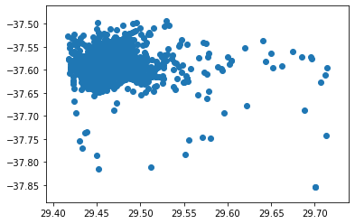

```python
plt.scatter(px, py)
```

[output not shown]

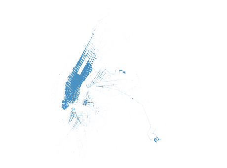

```python
plt.figure(figsize=(8, 6))
plt.scatter(px, py, s=.1, alpha=.03)
plt.axis('equal')
plt.xlim(29.40, 29.55)
plt.ylim(-37.63, -37.54)
plt.axis('off')
```

### Descriptive statistics with pandas and seaborn

```python
px.count(), px.min(), px.max()
```

```
(846945, 29.417137499999995, 29.71431305555556)
```

```python
px.mean(), px.median(), px.std()
```

```
(29.45134580776863, 29.449418333333337, 0.009761694274451149)
```

```python
#!conda install seaborn -q -y
```

```python
import seaborn as sns
sns.__version__
```

[output not shown]

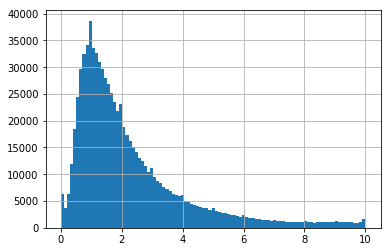

```python
data.trip_distance.hist(bins=np.linspace(0., 10., 100))
```

### References

- https://www.analyticsvidhya.com/blog/2016/01/complete-tutorial-learn-data-science-python-scratch-2/